# actuarial Data Science

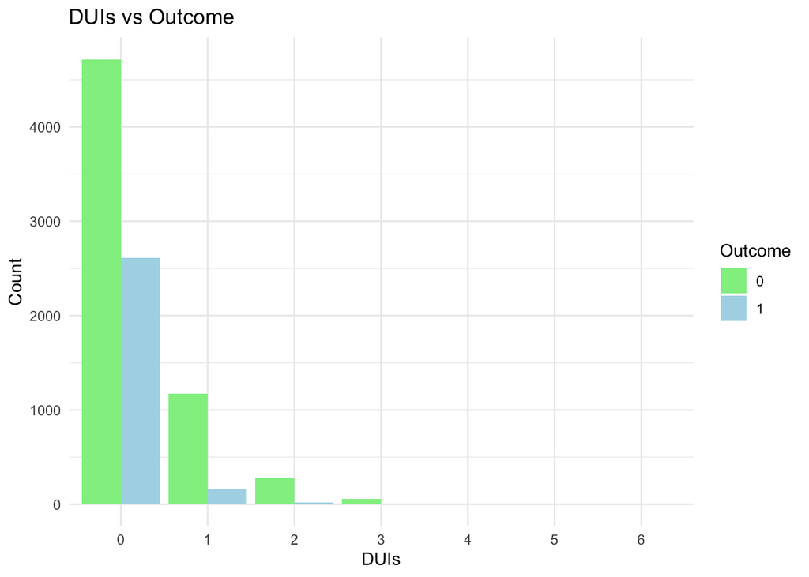

```r
# Bar chart for DUIS vs OUTCOME
ggplot(data_clean, aes(x = factor(DUIS), fill = factor(OUTCOME))) +
  geom_bar(position = "dodge") +
  scale_fill_manual(values = c(color_light_green, color_light_blue)) +
  labs(title = "DUIs vs Outcome", x = "DUIs", y = "Count", fill = "Outcome") +
  theme_minimal()
```

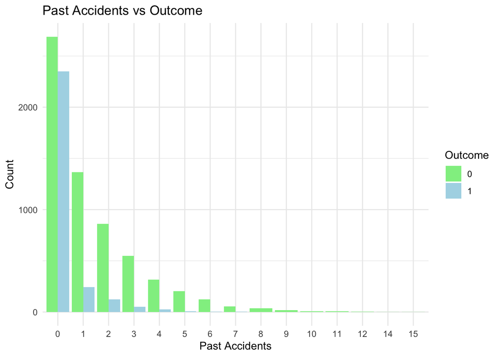

```r
# Bar chart for PAST_ACCIDENTS vs OUTCOME
ggplot(data_clean, aes(x = factor(PAST_ACCIDENTS), fill = factor(OUTCOME))) +
  geom_bar(position = "dodge") +
  scale_fill_manual(values = c(color_light_green, color_light_blue)) +
  labs(title = "Past Accidents vs Outcome", x = "Past Accidents", y = "Count", fill = "Outcome") +
  theme_minimal()
```

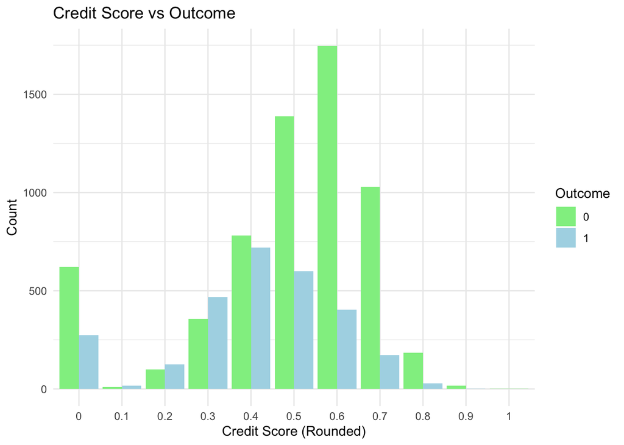

```r
# Bar chart for CREDIT_SCORE vs OUTCOME
ggplot(data_clean, aes(x = factor(round(CREDIT_SCORE, 1)), fill = factor(OUTCOME))) +
  geom_bar(position = "dodge") +
  scale_fill_manual(values = c(color_light_green, color_light_blue)) +
  labs(title = "Credit Score vs Outcome", x = "Credit Score (Rounded)", y = "Count", fill = "Outcome") +
  theme_minimal()
```

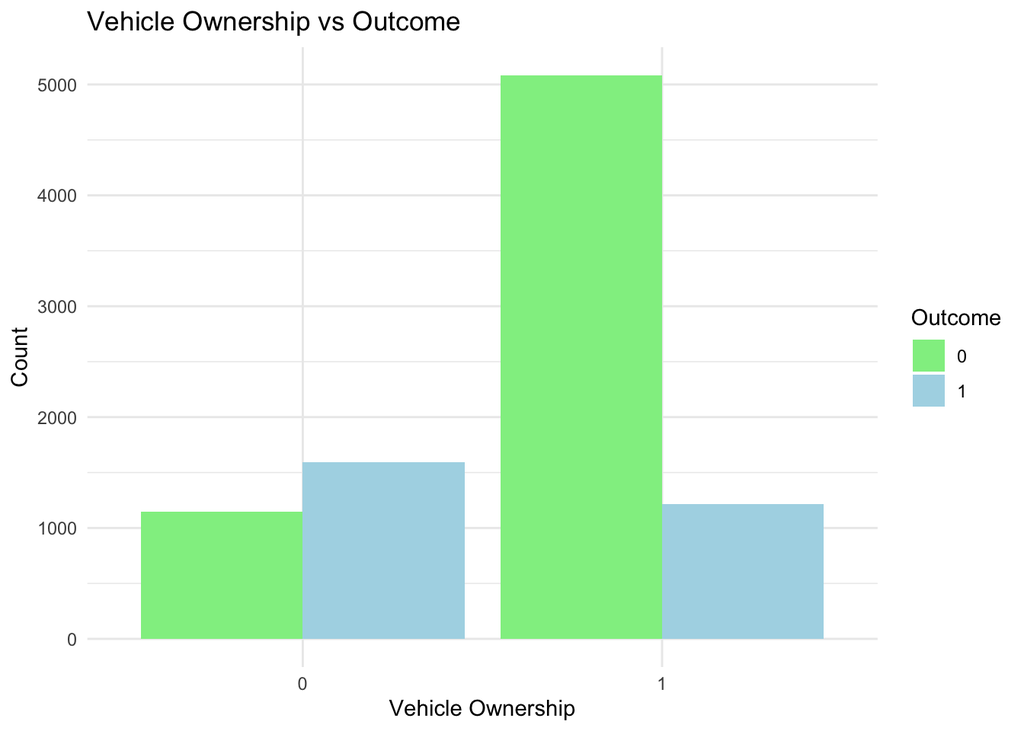

```r
# Bar chart for VEHICLE_OWNERSHIP vs OUTCOME
ggplot(data_clean, aes(x = factor(VEHICLE_OWNERSHIP), fill = factor(OUTCOME))) +
  geom_bar(position = "dodge") +
  scale_fill_manual(values = c(color_light_green, color_light_blue)) +
  labs(title = "Vehicle Ownership vs Outcome", x = "Vehicle Ownership", y = "Count", fill = "Outcome") +
  theme_minimal()
```

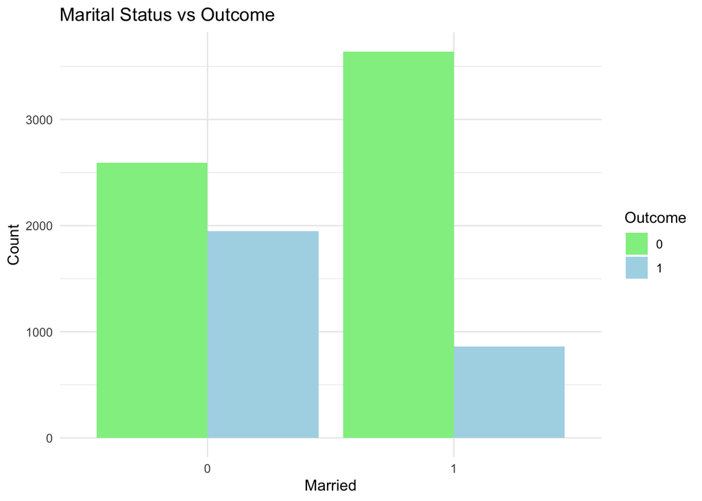

```r
# Bar chart for MARRIED vs OUTCOME
ggplot(data_clean, aes(x = factor(MARRIED), fill = factor(OUTCOME))) +
  geom_bar(position = "dodge") +
  scale_fill_manual(values = c(color_light_green, color_light_blue)) +
  labs(title = "Marital Status vs Outcome", x = "Married", y = "Count", fill = "Outcome") +
  theme_minimal()
```

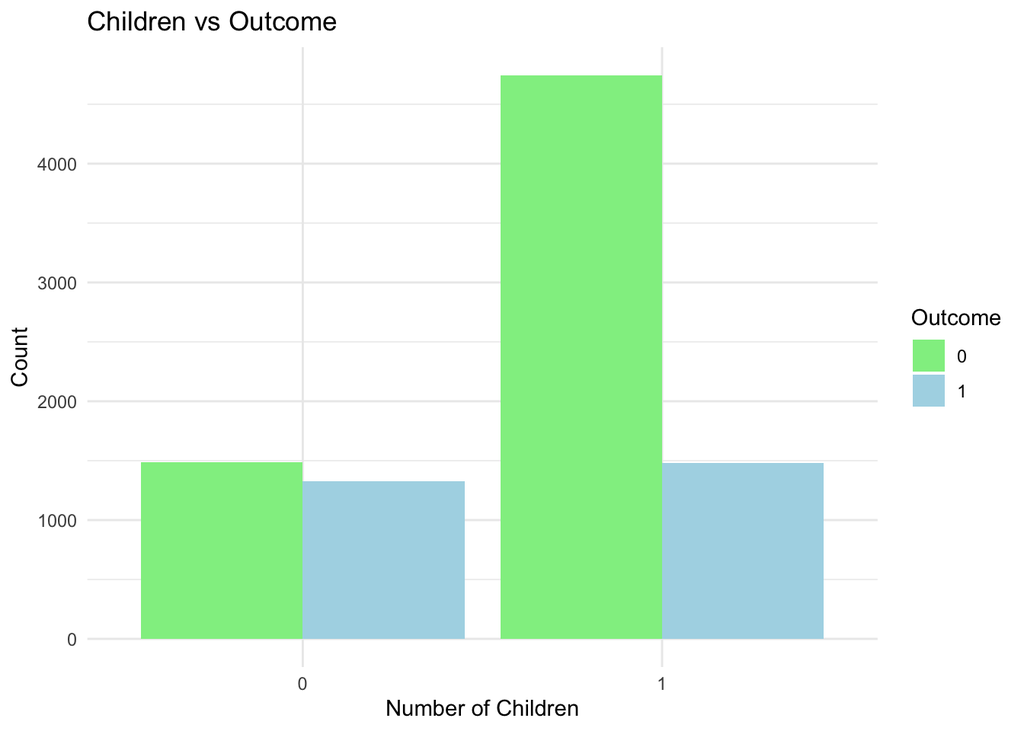

```r
# Bar chart for CHILDREN vs OUTCOME
ggplot(data_clean, aes(x = factor(CHILDREN), fill = factor(OUTCOME))) +
  geom_bar(position = "dodge") +
  scale_fill_manual(values = c(color_light_green, color_light_blue)) +
  labs(title = "Children vs Outcome", x = "Number of Children", y = "Count", fill = "Outcome") +
  theme_minimal()
```

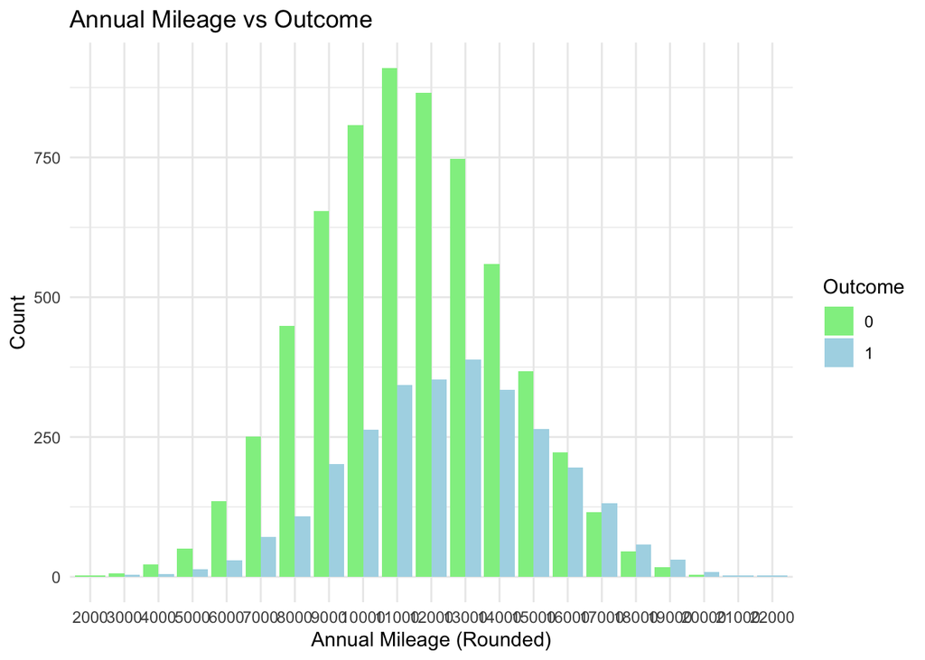

```r
# Bar chart for ANNUAL_MILEAGE vs OUTCOME
ggplot(data_clean, aes(x = factor(round(ANNUAL_MILEAGE, -3)), fill = factor(OUTCOME))) +
  geom_bar(position = "dodge") +
  scale_fill_manual(values = c(color_light_green, color_light_blue)) +
  labs(title = "Annual Mileage vs Outcome", x = "Annual Mileage (Rounded)", y = "Count", fill = "Outcome") +
  theme_minimal()
```

## Step - 3 splitting the dataset for logistic regression regression analysis(Training & Testing)

```r
# Load necessary libraries
library(dplyr)
library(caret)

# Assume data_clean is your prepared dataset
# Encode categorical variables as factors
data_clean <- data_clean %>%
  mutate(
    AGE = as.factor(AGE),
    GENDER = as.factor(GENDER),
    RACE = as.factor(RACE),
    VEHICLE_YEAR = as.factor(VEHICLE_YEAR),
    VEHICLE_TYPE = as.factor(VEHICLE_TYPE),
    EDUCATION = as.factor(EDUCATION),
    INCOME = as.factor(INCOME),
    DRIVING_EXPERIENCE = as.factor(DRIVING_EXPERIENCE),
    POSTAL_CODE = as.factor(POSTAL_CODE),
    VEHICLE_OWNERSHIP = as.factor(VEHICLE_OWNERSHIP),
    MARRIED = as.factor(MARRIED),
    CHILDREN = as.factor(CHILDREN),
    OUTCOME = as.factor(OUTCOME) # Ensure outcome is a factor for logistic regression
  )

# Remove unnecessary columns if any
# Example: data_clean <- data_clean %>% select(-ID) # Assuming ID was already removed

# Split the data into training and testing sets (80% training, 20% testing)
set.seed(123) # For reproducibility
trainIndex <- createDataPartition(data_clean$OUTCOME, p = 0.8, list = FALSE, times = 1)
trainData <- data_clean[trainIndex, ]
testData <- data_clean[-trainIndex, ]

# Verify the split
cat("Training set size:", nrow(trainData), "\n")
```

```
## Training set size: 7235
```

```r
cat("Testing set size:", nrow(testData), "\n")
```

```
## Testing set size: 1808
```

```r
# Load necessary libraries
library(MASS)   # For stepAIC
library(stats)  # For glm

# Fit the full model with all predictors
full_model <- glm(OUTCOME ~ ., data = trainData, family = binomial)

# Fit the null model (intercept only)
null_model <- glm(OUTCOME ~ 1, data = trainData, family = binomial)

# Forward Selection
forward_model <- stepAIC(null_model,
                         scope = list(lower = null_model, upper = full_model),
                         direction = "forward",
                         trace = FALSE)

cat("Forward Selection Model:\n")
```

```
## Forward Selection Model:
```

```r
print(summary(forward_model))
```

```
##
## Call:
## glm(formula = OUTCOME ~ DRIVING_EXPERIENCE + VEHICLE_OWNERSHIP +
##     POSTAL_CODE + VEHICLE_YEAR + GENDER + ANNUAL_MILEAGE + MARRIED +
##     DUIS + PAST_ACCIDENTS, family = binomial, data = trainData)
##
## Coefficients:
##                            Estimate Std. Error z value Pr(>|z|)
## (Intercept)              -1.871e+00  2.506e-01  -7.469 8.07e-14 ***
## DRIVING_EXPERIENCE10-19y -2.105e+00  9.572e-02 -21.995  < 2e-16 ***
## DRIVING_EXPERIENCE20-29y -4.188e+00  1.913e-01 -21.895  < 2e-16 ***
## DRIVING_EXPERIENCE30y+   -5.384e+00  4.520e-01 -11.912  < 2e-16 ***
## VEHICLE_OWNERSHIP1       -1.966e+00  8.125e-02 -24.198  < 2e-16 ***
## POSTAL_CODE21217          2.114e+01  1.771e+02   0.119   0.9050
## POSTAL_CODE32765          1.300e+00  9.675e-02  13.436  < 2e-16 ***
## POSTAL_CODE92101          1.711e+00  1.768e-01   9.676  < 2e-16 ***
## VEHICLE_YEARbefore 2015   1.926e+00  1.004e-01  19.175  < 2e-16 ***
## GENDERmale                1.063e+00  7.849e-02  13.547  < 2e-16 ***
## ANNUAL_MILEAGE            1.234e-04  1.620e-05   7.618 2.58e-14 ***
## MARRIED1                 -3.458e-01  8.605e-02  -4.019 5.85e-05 ***
## DUIS                      1.575e-01  9.319e-02   1.690   0.0911 .
## PAST_ACCIDENTS           -7.128e-02  4.618e-02  -1.543   0.1227
## ---
## Signif. codes:  0 '***' 0.001 '**' 0.01 '*' 0.05 '.' 0.1 ' ' 1
##
## (Dispersion parameter for binomial family taken to be 1)
##
##     Null deviance: 8966.6  on 7234  degrees of freedom
## Residual deviance: 4603.8  on 7221  degrees of freedom
## AIC: 4631.8
##
## Number of Fisher Scoring iterations: 15
```

```r
# Backward Selection
backward_model <- stepAIC(full_model,
                          direction = "backward",
                          trace = FALSE)

cat("\nBackward Selection Model:\n")
```

```
##
## Backward Selection Model:
```

```r
print(summary(backward_model))
```

```
##
## Call:
## glm(formula = OUTCOME ~ GENDER + DRIVING_EXPERIENCE + VEHICLE_OWNERSHIP +
##     VEHICLE_YEAR + MARRIED + POSTAL_CODE + ANNUAL_MILEAGE + DUIS +
##     PAST_ACCIDENTS, family = binomial, data = trainData)
##
## Coefficients:
##                            Estimate Std. Error z value Pr(>|z|)
## (Intercept)              -1.871e+00  2.506e-01  -7.469 8.07e-14 ***
## GENDERmale                1.063e+00  7.849e-02  13.547  < 2e-16 ***
## DRIVING_EXPERIENCE10-19y -2.105e+00  9.572e-02 -21.995  < 2e-16 ***
## DRIVING_EXPERIENCE20-29y -4.188e+00  1.913e-01 -21.895  < 2e-16 ***
## DRIVING_EXPERIENCE30y+   -5.384e+00  4.520e-01 -11.912  < 2e-16 ***
## VEHICLE_OWNERSHIP1       -1.966e+00  8.125e-02 -24.198  < 2e-16 ***
## VEHICLE_YEARbefore 2015   1.926e+00  1.004e-01  19.175  < 2e-16 ***
## MARRIED1                 -3.458e-01  8.605e-02  -4.019 5.85e-05 ***
## POSTAL_CODE21217          2.114e+01  1.771e+02   0.119   0.9050
## POSTAL_CODE32765          1.300e+00  9.675e-02  13.436  < 2e-16 ***
## POSTAL_CODE92101          1.711e+00  1.768e-01   9.676  < 2e-16 ***
## ANNUAL_MILEAGE            1.234e-04  1.620e-05   7.618 2.58e-14 ***
## DUIS                      1.575e-01  9.319e-02   1.690   0.0911 .
## PAST_ACCIDENTS           -7.128e-02  4.618e-02  -1.543   0.1227
## ---
## Signif. codes:  0 '***' 0.001 '**' 0.01 '*' 0.05 '.' 0.1 ' ' 1
##
## (Dispersion parameter for binomial family taken to be 1)
##
##     Null deviance: 8966.6  on 7234  degrees of freedom
## Residual deviance: 4603.8  on 7221  degrees of freedom
## AIC: 4631.8
##
## Number of Fisher Scoring iterations: 15
```

```r
# Stepwise Selection
stepwise_model <- stepAIC(null_model,
                          scope = list(lower = null_model, upper = full_model),
                          direction = "both",
                          trace = FALSE)

cat("\nStepwise Selection Model:\n")
```

```
##
## Stepwise Selection Model:
```

```r
print(summary(stepwise_model))
```

```
##
## Call:
## glm(formula = OUTCOME ~ DRIVING_EXPERIENCE + VEHICLE_OWNERSHIP +
##     POSTAL_CODE + VEHICLE_YEAR + GENDER + ANNUAL_MILEAGE + MARRIED +
##     DUIS + PAST_ACCIDENTS, family = binomial, data = trainData)
##
## Coefficients:
##                            Estimate Std. Error z value Pr(>|z|)
## (Intercept)              -1.871e+00  2.506e-01  -7.469 8.07e-14 ***
## DRIVING_EXPERIENCE10-19y -2.105e+00  9.572e-02 -21.995  < 2e-16 ***
## DRIVING_EXPERIENCE20-29y -4.188e+00  1.913e-01 -21.895  < 2e-16 ***
## DRIVING_EXPERIENCE30y+   -5.384e+00  4.520e-01 -11.912  < 2e-16 ***
## VEHICLE_OWNERSHIP1       -1.966e+00  8.125e-02 -24.198  < 2e-16 ***
## POSTAL_CODE21217          2.114e+01  1.771e+02   0.119   0.9050
## POSTAL_CODE32765          1.300e+00  9.675e-02  13.436  < 2e-16 ***
## POSTAL_CODE92101          1.711e+00  1.768e-01   9.676  < 2e-16 ***
## VEHICLE_YEARbefore 2015   1.926e+00  1.004e-01  19.175  < 2e-16 ***
## GENDERmale                1.063e+00  7.849e-02  13.547  < 2e-16 ***
## ANNUAL_MILEAGE            1.234e-04  1.620e-05   7.618 2.58e-14 ***
## MARRIED1                 -3.458e-01  8.605e-02  -4.019 5.85e-05 ***
## DUIS                      1.575e-01  9.319e-02   1.690   0.0911 .
## PAST_ACCIDENTS           -7.128e-02  4.618e-02  -1.543   0.1227
## ---
## Signif. codes:  0 '***' 0.001 '**' 0.01 '*' 0.05 '.' 0.1 ' ' 1
##
## (Dispersion parameter for binomial family taken to be 1)
##
##     Null deviance: 8966.6  on 7234  degrees of freedom
## Residual deviance: 4603.8  on 7221  degrees of freedom
## AIC: 4631.8
##
## Number of Fisher Scoring iterations: 15
```

### This logistic regression model analyzes factors influencing an insurance-related outcome. The model significantly reduces residual deviance from 8966.6 to 4603.8, indicating a strong fit. The AIC of 4631.8 suggests effective model efficiency compared to a baseline model.

### Key findings include:

- **Driving Experience**: More years are strongly protective against the outcome, with those having 30+ years showing the most substantial decrease in risk.
- **Vehicle Ownership**: Owning a vehicle significantly decreases the likelihood of the outcome.
- **Vehicle Year**: Older vehicles (pre-2015) are associated with higher risk.
- **Gender**: Males have a higher likelihood of the outcome occurring.
- **Marital Status**: Married individuals present lower risk.

**Postal Codes** and **Annual Mileage** also contribute to risk levels, but with varying significance. DUIs and past accidents, while directionally impactful, aren’t statistically significant at traditional levels.

### From an actuarial standpoint, these results are crucial for refining risk profiles, optimizing premium settings, and improving customer segmentation in the insurance industry. This robust model aids in understanding critical risk factors, facilitating strategic decision-making.

```r
# Predict on the test data using the stepwise model
testData$predicted_probs_stepwise <- predict(stepwise_model, newdata = testData, type = "response")

# Convert probabilities to binary outcomes (using 0.5 as the threshold)
testData$predicted_outcome_stepwise <- ifelse(testData$predicted_probs_stepwise > 0.5, 1, 0)

# Evaluate the model with a confusion matrix
conf_matrix_stepwise <- confusionMatrix(factor(testData$predicted_outcome_stepwise), testData$OUTCOME)

# Print the confusion matrix and other metrics
print(conf_matrix_stepwise)
```

```
## Confusion Matrix and Statistics
##
##           Reference
## Prediction    0    1
##          0 1113  153
##          1  133  409
##
##                Accuracy : 0.8418
##                  95% CI : (0.8242, 0.8583)
##     No Information Rate : 0.6892
##     P-Value [Acc > NIR] : <2e-16
##
##                   Kappa : 0.6271
##
##  Mcnemar's Test P-Value : 0.2612
##
##             Sensitivity : 0.8933
##             Specificity : 0.7278
##          Pos Pred Value : 0.8791
##          Neg Pred Value : 0.7546
##              Prevalence : 0.6892
##          Detection Rate : 0.6156
##    Detection Prevalence : 0.7002
##       Balanced Accuracy : 0.8105
##
##        'Positive' Class : 0
##
```

```r
# Calculate and print AUC for the stepwise model
roc_curve_stepwise <- roc(testData$OUTCOME, testData$predicted_probs_stepwise)
auc_value_stepwise <- auc(roc_curve_stepwise)
cat("AUC for Stepwise Model:", auc_value_stepwise, "\n")
```

```
## AUC for Stepwise Model: 0.9175618
```

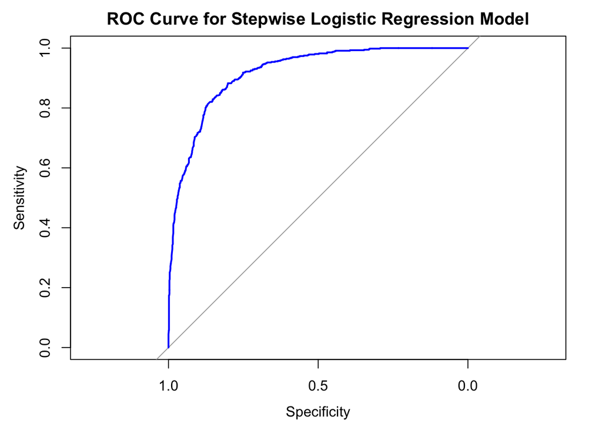

```r
# Plot ROC curve for the stepwise model
plot(roc_curve_stepwise, col = "blue", main = "ROC Curve for Stepwise Logistic Regression Model")
```

```r
# Load necessary library
library(caret)  # For confusionMatrix

# Fit the logistic regression model with all variables
logistic_model <- glm(OUTCOME ~ ., data = trainData, family = binomial)

# Summary of the logistic regression model
summary(logistic_model)
```

```
##
## Call:
## glm(formula = OUTCOME ~ ., family = binomial, data = trainData)
##
## Coefficients:
##                            Estimate Std. Error z value Pr(>|z|)
## (Intercept)              -1.965e+00  3.275e-01  -6.000 1.98e-09 ***
## AGE26-39                 -8.505e-02  1.257e-01  -0.676 0.498795
## AGE40-64                  2.749e-02  1.489e-01   0.185 0.853540
## AGE65+                   -7.220e-02  1.883e-01  -0.383 0.701384
## GENDERmale                1.073e+00  8.047e-02  13.338  < 2e-16 ***
## RACEminority             -1.200e-01  1.224e-01  -0.981 0.326666
## DRIVING_EXPERIENCE10-19y -2.052e+00  1.241e-01 -16.532  < 2e-16 ***
## DRIVING_EXPERIENCE20-29y -4.226e+00  2.341e-01 -18.056  < 2e-16 ***
## DRIVING_EXPERIENCE30y+   -5.358e+00  5.030e-01 -10.652  < 2e-16 ***
## EDUCATIONnone            -1.205e-02  1.032e-01  -0.117 0.906992
## EDUCATIONuniversity      -4.267e-02  9.433e-02  -0.452 0.651042
## INCOMEpoverty             2.310e-01  1.349e-01   1.712 0.086887 .
## INCOMEupper class         5.931e-02  1.230e-01   0.482 0.629681
## INCOMEworking class       1.725e-01  1.158e-01   1.489 0.136360
## CREDIT_SCORE              3.410e-01  2.245e-01   1.519 0.128713
## VEHICLE_OWNERSHIP1       -1.936e+00  8.628e-02 -22.440  < 2e-16 ***
## VEHICLE_YEARbefore 2015   1.897e+00  1.049e-01  18.083  < 2e-16 ***
## MARRIED1                 -3.159e-01  8.970e-02  -3.522 0.000428 ***
## CHILDREN1                -8.896e-02  8.887e-02  -1.001 0.316839
## POSTAL_CODE21217          2.112e+01  1.776e+02   0.119 0.905328
## POSTAL_CODE32765          1.276e+00  1.013e-01  12.589  < 2e-16 ***
## POSTAL_CODE92101          1.717e+00  1.778e-01   9.657  < 2e-16 ***
## ANNUAL_MILEAGE            1.162e-04  1.796e-05   6.467 9.98e-11 ***
## VEHICLE_TYPEsports car   -4.439e-02  1.744e-01  -0.254 0.799112
## SPEEDING_VIOLATIONS       1.794e-02  3.316e-02   0.541 0.588490
## DUIS                      1.501e-01  9.380e-02   1.600 0.109604
## PAST_ACCIDENTS           -7.177e-02  4.634e-02  -1.549 0.121409
## ---
## Signif. codes:  0 '***' 0.001 '**' 0.01 '*' 0.05 '.' 0.1 ' ' 1
##
## (Dispersion parameter for binomial family taken to be 1)
##
##     Null deviance: 8966.6  on 7234  degrees of freedom
## Residual deviance: 4594.6  on 7208  degrees of freedom
## AIC: 4648.6
##
## Number of Fisher Scoring iterations: 15
```